# Practical Machine Learning Course Project

Mike Silva

January 2015

## Background

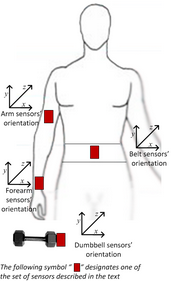

Six young health participants were asked to perform one set of 10 repetitions of the unilateral dumbbell biceps curl in five different fashions: exactly according to the specification (Class A), throwing the elbows to the front (Class B), lifting the dumbbell only halfway (Class C), lowering the dumbbell only halfway (Class D) and throwing the hips to the front (Class E). These activites were monitored with on-body wearable accelerometers.

[http://groupware.les.inf.puc-rio.br/har#weight_lifting_exercises]

## Machine Learning Task

The task is to develop a model that predicts what activity is being preformed based on the data that was collected.

## Code

First I loaded the libraries needed for the analysis and set the random number generator seed to 3.14.

```r
library(caret)
library(rattle)
set.seed(3.14)
```

### Loading and Cleaning Data

Next I download the data if it doesn’t exist locally:

```r
training.file <- 'pml-training.csv'
if(!file.exists(training.file)){
  download.file('http://d396qusza40orc.cloudfront.net/predmachlearn/pml-training.csv', training.file)
}
testing.file <- 'pml-testing.csv'
if(!file.exists(testing.file)){
  download.file('http://d396qusza40orc.cloudfront.net/predmachlearn/pml-testing.csv', testing.file)
}
```

I then loaded the data and standardized the missing values:

```r
training <- read.csv(training.file, na.strings=c('NA','#DIV/0!',''))
testing <- read.csv(testing.file, na.strings=c('NA','#DIV/0!',''))
```

Initially there are 160 features. I removed all features that have are nothing but missing values:

```r
training <- training[,colSums(is.na(training)) == 0]
testing <- testing[,colSums(is.na(testing)) == 0]
```

I am left with 60 features. Next we delete the first 7 features (X, user_name, raw_timestamp_part_1, raw_timestamp_part_2, cvtd_timestamp, new_window, num_window) as they are not useful in forming a prediction model:

```r
training <- training[, -c(1:7)]
testing <- testing[, -c(1:7)]
```

I am now left with 53 features for the analysis. A sample of the data is given in the appendix.

## Partitionaning Data Set

The training set contains 19622 observations. In order to cross validate the models I partitioned the training data into two subsets.

```r
subset <- createDataPartition(y=training$classe, p=0.75, list=FALSE)
subset.for.training <- training[subset,]
subset.for.testing <- training[-subset,]
```

## Modeling Approaches

### Recursive Partitioning and Regression Trees

I selected this approach to form a baseline. I did not expect this to provide a reliable prediction model. However I needed something to compair the other models against.

```r
rpart.fit <- train(classe~., data=subset.for.training, method='rpart')
predict.rpart <- predict(rpart.fit, subset.for.testing)
#fancyRpartPlot(rpart.fit $finalModel)
confusionMatrix(predict.rpart, subset.for.testing$classe)
```

[output not shown]

### Naive Bayes

I selected this approach because I am a big fan of the Baysian approach in statistical modeling and I wanted to get some practical experience with it.

```r
nb.fit <- train(classe ~ ., data=subset.for.training, method="nb")
predict.nb <- predict(nb.fit, subset.for.testing)
confusionMatrix(predict.nb, subset.for.testing$classe)
```

[output not shown]

### Random Forest

I selected this approach out of curiosity to see if it could out preform the Baysian model.

```r
rf.fit <- train(classe ~ ., data = subset.for.training, method = 'rf',
                trControl = trainControl(method = "cv", number = 4, allowParallel = TRUE))
predict.rf <- predict(rf.fit, subset.for.testing)
confusionMatrix(predict.rf, subset.for.testing$classe)
```

[output not shown]

# Appendix 1: Sample Data

| roll_belt | pitch_belt | yaw_belt | total_accel_belt | gyros_belt_x | gyros_belt_y | gyros_belt_z | accel_belt_x | accel_belt_y | accel_belt_z | magnet_belt_x | magnet_belt_y | magnet_belt_z | roll_arm | pitch_arm | yaw_arm | total_accel_arm | gyros_arm_x | gyros_arm_y | gyros_arm_z | accel_arm_x | accel_arm_y | accel_arm_z | magnet_arm_x | magnet_arm_y | magnet_arm_z | roll_dumbbell | pitch_dumbbell | yaw_dumbbell | total_accel_dumbbell | … |
| --- | --- | --- | --- | --- | --- | --- | --- | --- | --- | --- | --- | --- | --- | --- | --- | --- | --- | --- | --- | --- | --- | --- | --- | --- | --- | --- | --- | --- | --- | --- |
| 1.41 | 8.07 | -94.4 | 3 | 0 | 0 | -0.02 | -21 | 4 | 22 | -3 | 599 | -313 | -128 | 22.5 | -161 | 34 | 0 | 0 | -0.02 | -288 | 109 | -123 | -368 | 337 | 516 | 13.05 | -70.49 | -84.87 | 37 | … |
| 1.41 | 8.07 | -94.4 | 3 | 0.02 | 0 | -0.02 | -22 | 4 | 22 | -7 | 608 | -311 | -128 | 22.5 | -161 | 34 | 0.02 | -0.02 | -0.02 | -290 | 110 | -125 | -369 | 337 | 513 | 13.13 | -70.64 | -84.71 | 37 | … |
| 1.42 | 8.07 | -94.4 | 3 | 0 | 0 | -0.02 | -20 | 5 | 23 | -2 | 600 | -305 | -128 | 22.5 | -161 | 34 | 0.02 | -0.02 | -0.02 | -289 | 110 | -126 | -368 | 344 | 513 | 12.85 | -70.28 | -85.14 | 37 | … |
| 1.48 | 8.05 | -94.4 | 3 | 0.02 | 0 | -0.03 | -22 | 3 | 21 | -6 | 604 | -310 | -128 | 22.1 | -161 | 34 | 0.02 | -0.03 | 0.02 | -289 | 111 | -123 | -372 | 344 | 512 | 13.43 | -70.39 | -84.87 | 37 | … |
| 1.48 | 8.07 | -94.4 | 3 | 0.02 | 0.02 | -0.02 | -21 | 2 | 24 | -6 | 600 | -302 | -128 | 22.1 | -161 | 34 | 0 | -0.03 | 0 | -289 | 111 | -123 | -374 | 337 | 506 | 13.38 | -70.43 | -84.85 | 37 | … |
| 1.45 | 8.06 | -94.4 | 3 | 0.02 | 0 | -0.02 | -21 | 4 | 21 | 0 | 603 | -312 | -128 | 22 | -161 | 34 | 0.02 | -0.03 | 0 | -289 | 111 | -122 | -369 | 342 | 513 | 13.38 | -70.82 | -84.47 | 37 | … |